# Correlation of PM2.5 concentrations and SARS-CoV-2 infection

## Wavelet coherence analysis on countrywide average

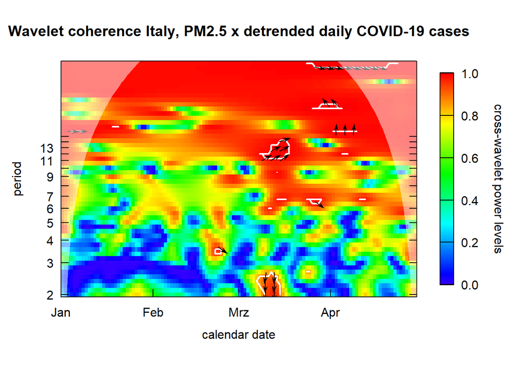

# Analyis 2: Dynmiac time warp clustering on countrywide average

The map shows clusters (different colors) with similar development of smoothed daily COVID-19 new infections. Cluster ID and number (n) of nuts 3 regions within each cluster is given in the legend.

[interactive chart not shown]

The plots show the average of daily PM2.5 and smoothed new infections along with their detrened infection series within each cluster. Cluster ID and number (n) of nuts 3 regions within each cluster is given in the figure headers.

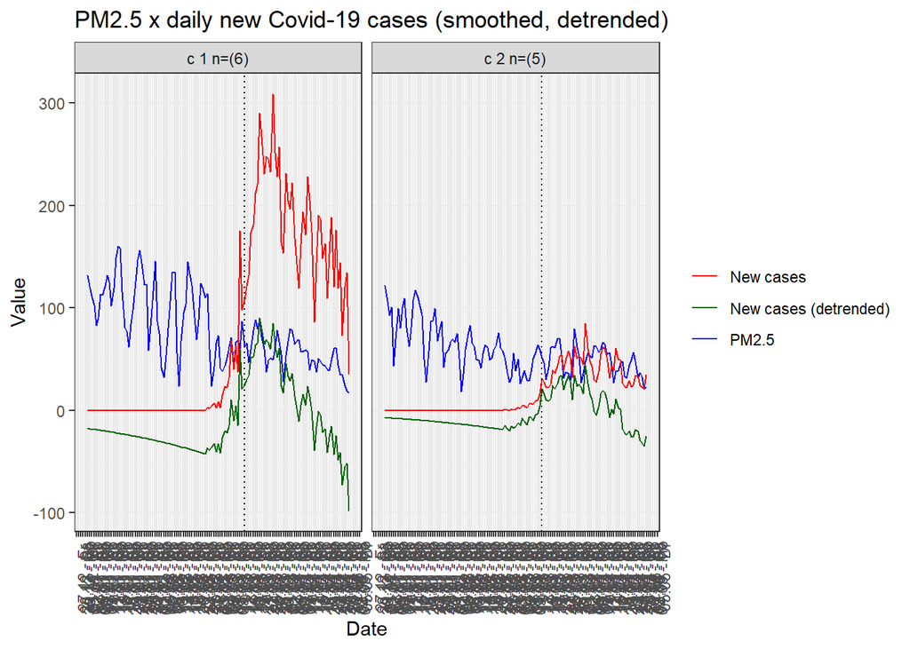

## Wavelet coherence analysis on cluster averages

The wavelet coherence analysis for each cluster reveals some considerable differences.

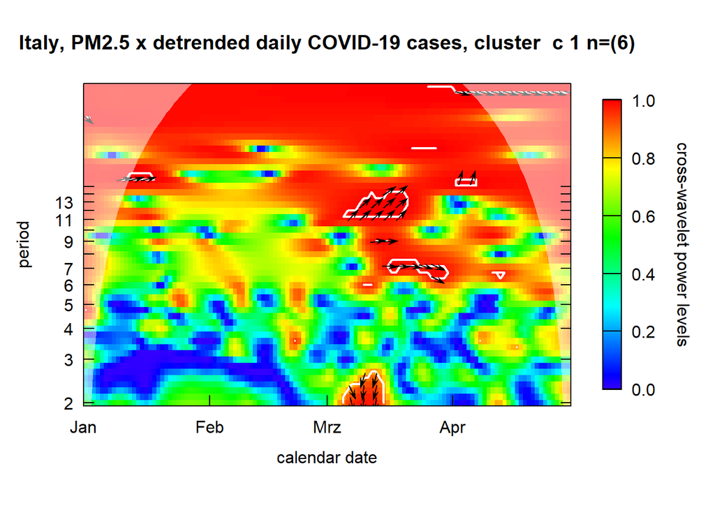

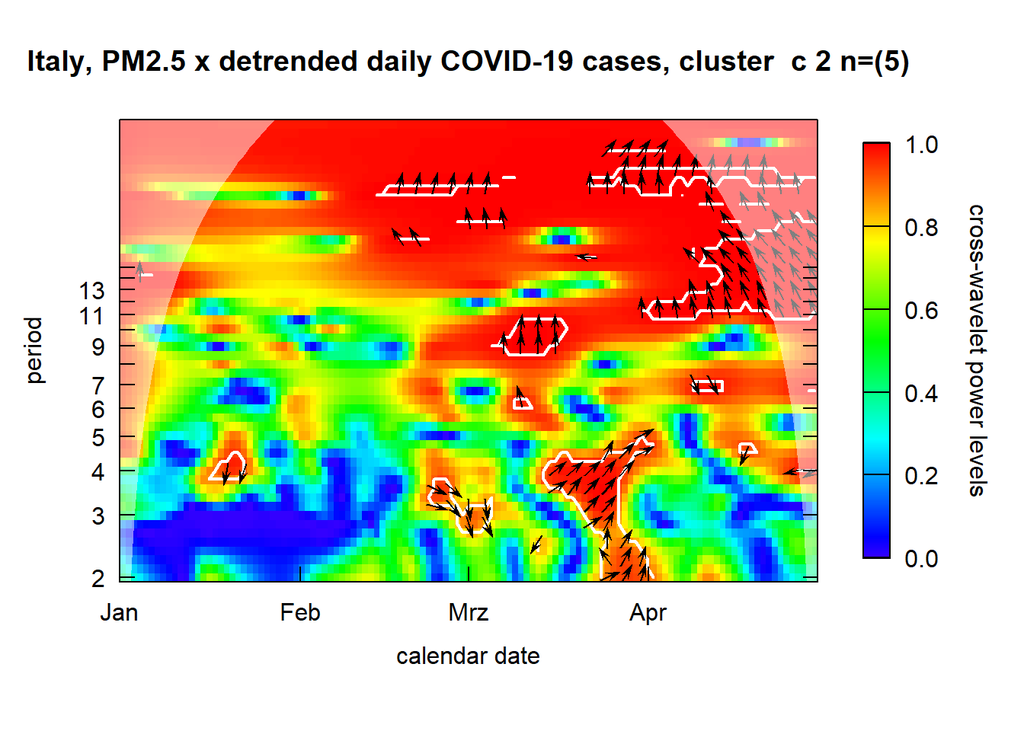

# Explanatory potential of PM2.5 for COVID-19 cases

## Generalized linear models

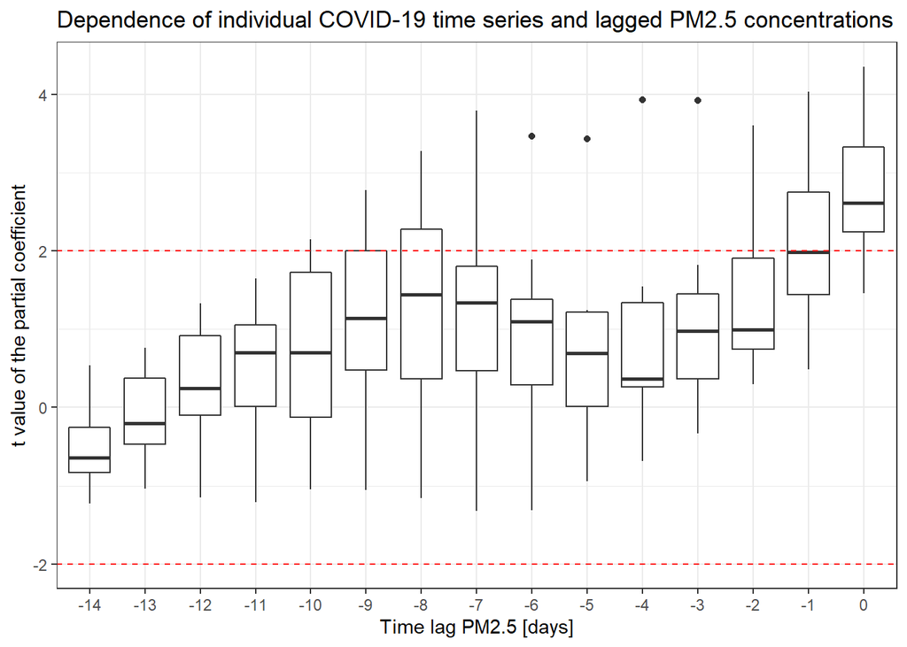

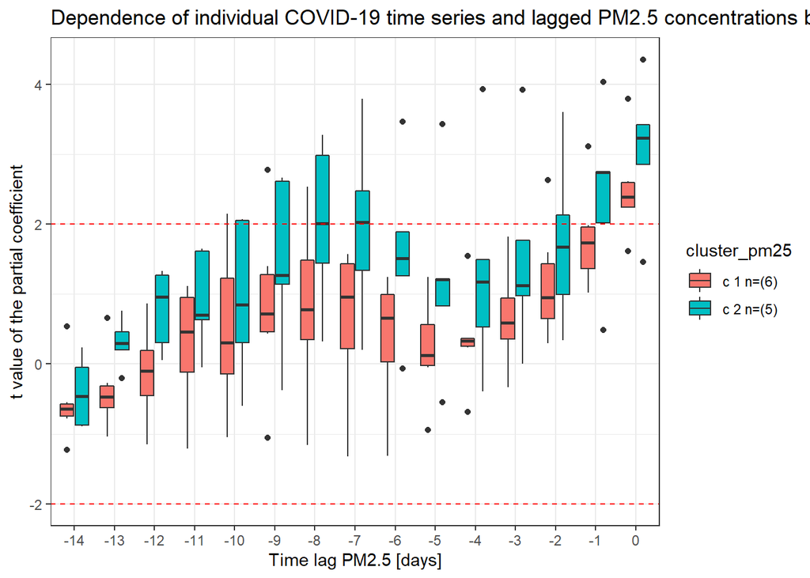

The following shows the R squared and t values resulting from a GLM model that relates the t value of the PM2.5 partial coefficient from the model above to latitude, longitude and area.

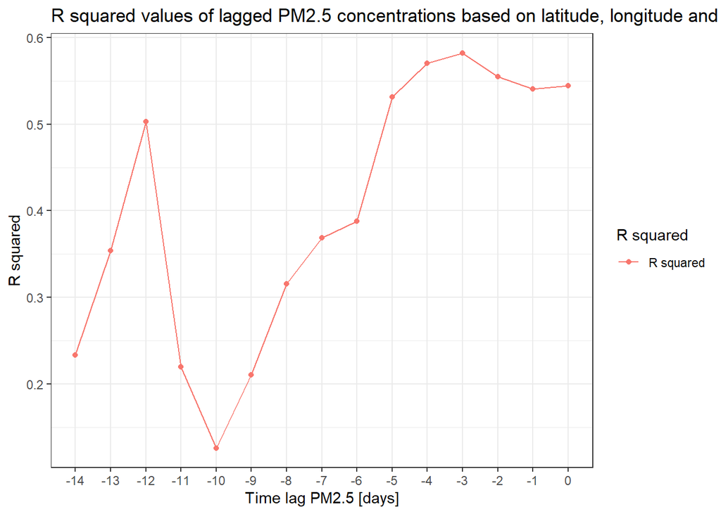

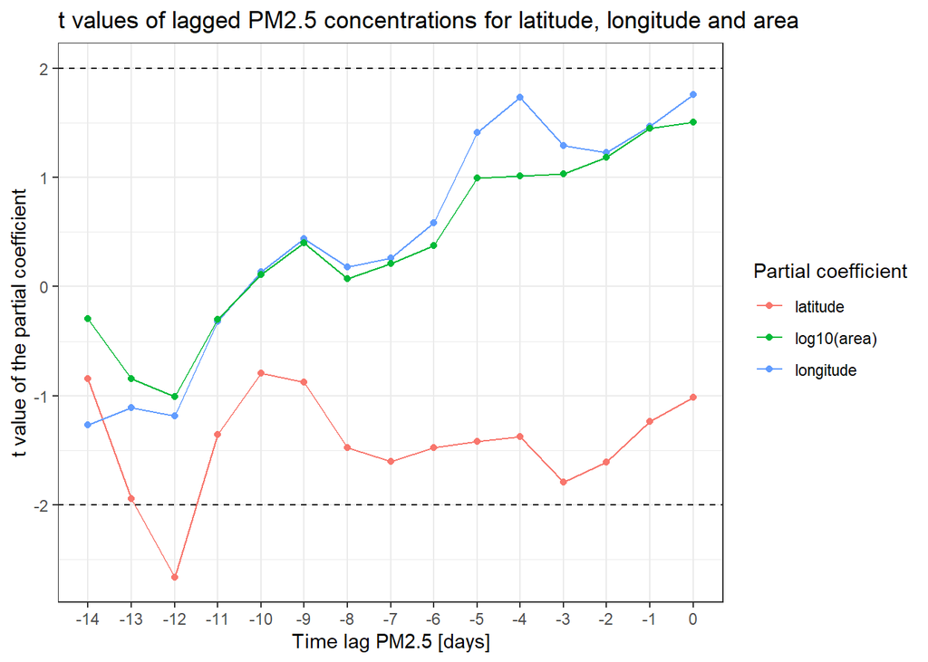

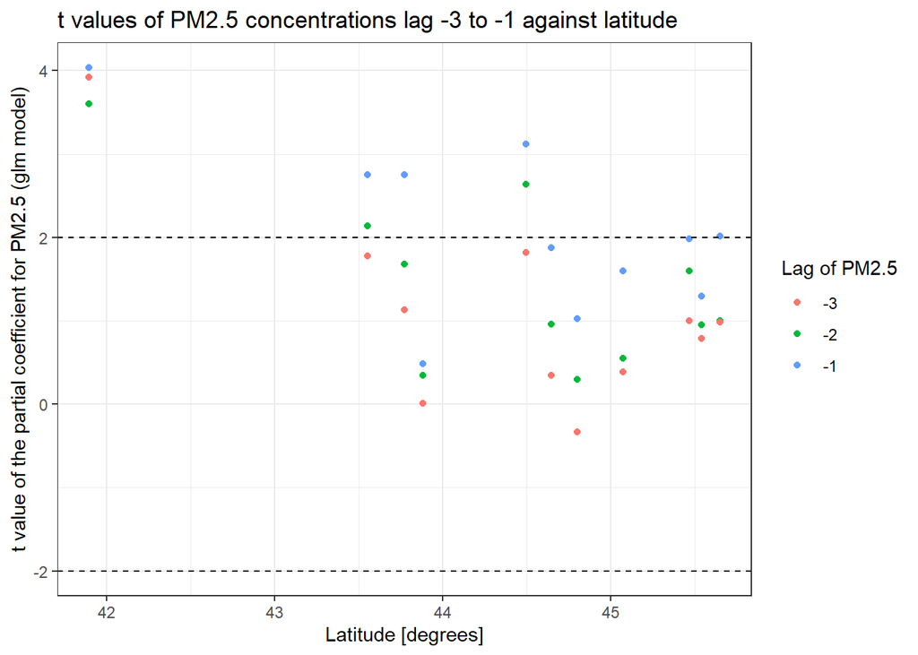

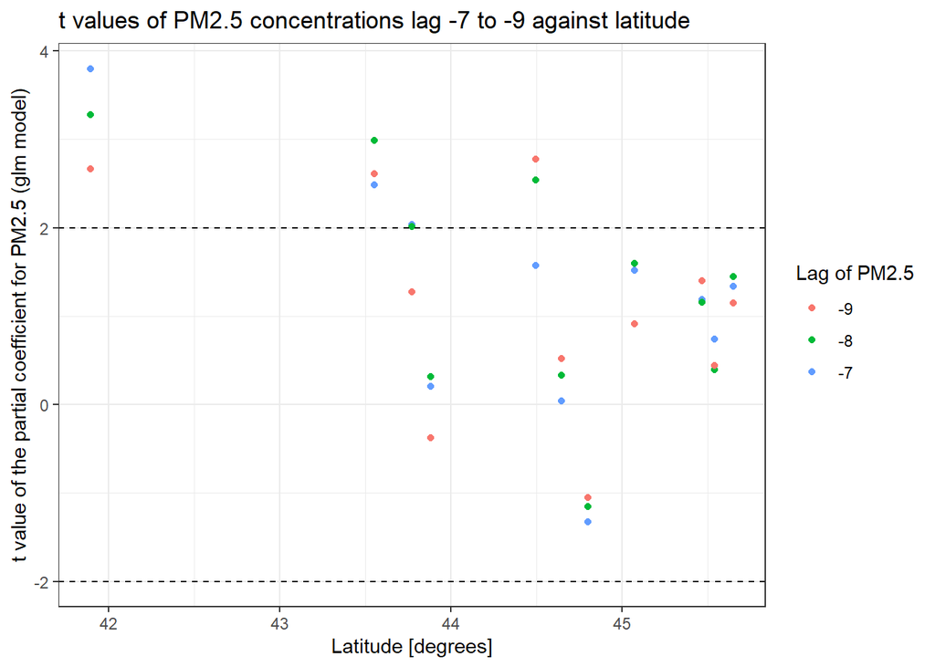

Hier mal ein Versuch, die Italien-Grafik in https://www.medrxiv.org/content/10.1101/2020.04.15.20065995v2 etwas nachzubauen. Auch hier - nur zufällig signifikant - ich vermute auch dort. Dafür sind bei unseren Italien-Daten die Cluster eindeutiger.

Italien vielleicht in Supplements?

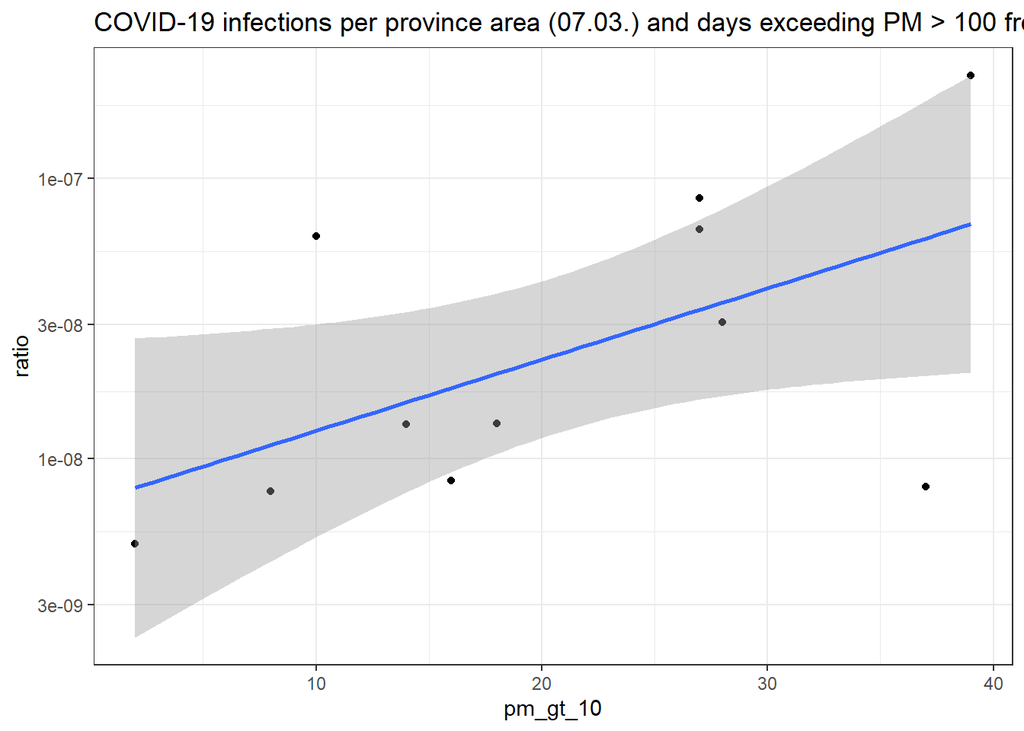

```
##
## Call:
## glm(formula = test_merge$ratio ~ test_merge$pm_gt_10, family = quasipoisson)
##
## Deviance Residuals:
##        Min          1Q      Median          3Q         Max
## -4.132e-04  -1.129e-04  -5.947e-05   7.883e-05   2.745e-04
##
## Coefficients:
##                      Estimate Std. Error t value Pr(>|t|)
## (Intercept)         -18.65855    0.85707 -21.770 4.29e-09 ***
## test_merge$pm_gt_10   0.07228    0.02783   2.597   0.0289 *
## ---
## Signif. codes:  0 '***' 0.001 '**' 0.01 '*' 0.05 '.' 0.1 ' ' 1
##
## (Dispersion parameter for quasipoisson family taken to be 4.123572e-08)
##
##     Null deviance: 6.9645e-07  on 10  degrees of freedom
## Residual deviance: 3.7691e-07  on  9  degrees of freedom
## AIC: NA
##
## Number of Fisher Scoring iterations: 18
```